# Prediction Using Exercise Data

### Summary:

This project uses prediction methods using physical activity data. The goal is to use data from accelerometers on the belt, forearm, arm, and dumbell of 6 participants. They were asked to perform barbell lifts correctly and incorrectly in 5 different ways, and we want to predict the manner in which they did the exercise.

##### Load and Clean Data

Load the necessary libraries and set random seed.

```r
library(caret)
```

```r
library(ggplot2)
library(randomForest)
set.seed(563962612)
```

Read in training and testing data.

```r
train <- read.csv("pml-training.csv")
test <- read.csv("pml-testing.csv")
```

Check how many observations and variables are in each dataset.

```r
dim(train); dim(test)
```

```
## [1] 19622   160
```

```
## [1]  20 160
```

Check to see how many variables have NA or blank values.

```r
na_sum <- sapply(train, function(x) sum(length(which(is.na(x))))+length(which(x=="")))
```

Delete the variables with NA values or blank values.

```r
train_nomissing <- train[,which(na_sum==0)]
```

We also need to delete the first seven variables in the data, which are not valid predictors of classe.

```r
names(train_nomissing)[1:7]
```

```
## [1] "X"                    "user_name"            "raw_timestamp_part_1"
## [4] "raw_timestamp_part_2" "cvtd_timestamp"       "new_window"
## [7] "num_window"
```

```r
train_clean <- train_nomissing[,-c(1:7)]
names(train_clean)
```

```
##  [1] "roll_belt"            "pitch_belt"           "yaw_belt"
##  [4] "total_accel_belt"     "gyros_belt_x"         "gyros_belt_y"
##  [7] "gyros_belt_z"         "accel_belt_x"         "accel_belt_y"
## [10] "accel_belt_z"         "magnet_belt_x"        "magnet_belt_y"
## [13] "magnet_belt_z"        "roll_arm"             "pitch_arm"
## [16] "yaw_arm"              "total_accel_arm"      "gyros_arm_x"
## [19] "gyros_arm_y"          "gyros_arm_z"          "accel_arm_x"
## [22] "accel_arm_y"          "accel_arm_z"          "magnet_arm_x"
## [25] "magnet_arm_y"         "magnet_arm_z"         "roll_dumbbell"
## [28] "pitch_dumbbell"       "yaw_dumbbell"         "total_accel_dumbbell"
## [31] "gyros_dumbbell_x"     "gyros_dumbbell_y"     "gyros_dumbbell_z"
## [34] "accel_dumbbell_x"     "accel_dumbbell_y"     "accel_dumbbell_z"
## [37] "magnet_dumbbell_x"    "magnet_dumbbell_y"    "magnet_dumbbell_z"
## [40] "roll_forearm"         "pitch_forearm"        "yaw_forearm"
## [43] "total_accel_forearm"  "gyros_forearm_x"      "gyros_forearm_y"
## [46] "gyros_forearm_z"      "accel_forearm_x"      "accel_forearm_y"
## [49] "accel_forearm_z"      "magnet_forearm_x"     "magnet_forearm_y"
## [52] "magnet_forearm_z"     "classe"
```

Keep same variables in the testing dataset.

```r
test_clean <- test[ , which(names(test) %in% names(train_clean))]
```

#### Pre-processing the Data

Check the values of the classe variable, which we are looking to predict.

```r
summary(train_clean$classe)
```

```
##    A    B    C    D    E
## 5580 3797 3422 3216 3607
```

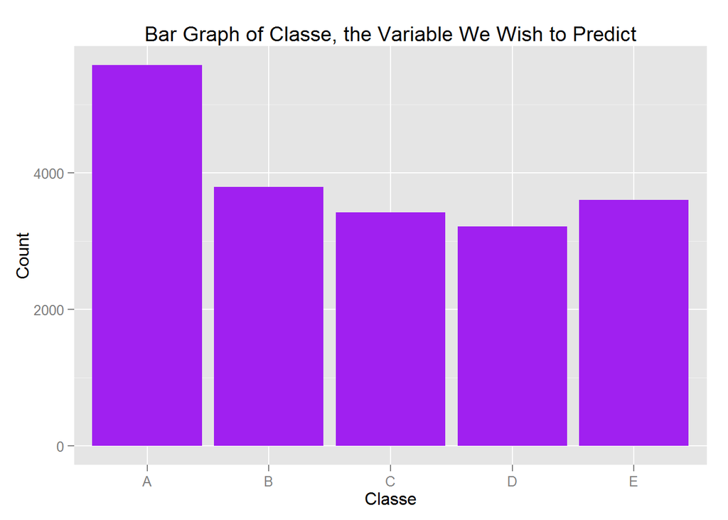

```r
ggplot(data=train_clean, aes(x=classe)) + geom_bar(stat="bin", fill="purple") + xlab("Classe") + ylab("Count")  + ggtitle("Bar Graph of Classe, the Variable We Wish to Predict")
```

We want to split our training dataset into a dataset that is used to build the model and a validation dataset to test the model.

```r
train_index <- createDataPartition(train_clean$classe, p=0.75, list=F)
train_true <- train_clean[train_index,]
train_validate <- train_clean[-train_index,]
```

#### Prediction Model

We will predict using random forests because it is a highly accurate and widely used prediction method. It works using bootstrap samples, which is essentially taking resamples of our observed data and our training data set. Then classification or regression trees are rebuilt on each of those bootstrap samples. When the data are split each time in a classification tree, the variables are also bootstrapped. In other words, only a subset of the variables is considered at each potential split. This makes for a diverse set of potential trees that can be built, so we grow a large number of trees. The trees are then averaged to get the prediction for a new outcome.

We will use 4-fold cross-validation in the algorithm.

```r
control_tr <- trainControl(method="cv", 4)
model1 <- train(classe ~ ., data=train_true, method="rf", trControl=control_tr,prox=TRUE)
model1; model1$finalModel
```

```
## Random Forest
##
## 14718 samples
##    52 predictor
##     5 classes: 'A', 'B', 'C', 'D', 'E'
##
## No pre-processing
## Resampling: Cross-Validated (4 fold)
##
## Summary of sample sizes: 11039, 11039, 11039, 11037
##
## Resampling results across tuning parameters:
##
##   mtry  Accuracy   Kappa      Accuracy SD  Kappa SD
##    2    0.9899445  0.9872798  0.002596595  0.003285349
##   27    0.9895369  0.9867642  0.003210641  0.004062022
##   52    0.9837618  0.9794581  0.004192983  0.005305327
##
## Accuracy was used to select the optimal model using  the largest value.
## The final value used for the model was mtry = 2.
```

```
##
## Call:
##  randomForest(x = x, y = y, mtry = param$mtry, proximity = TRUE)
##                Type of random forest: classification
##                      Number of trees: 500
## No. of variables tried at each split: 2
##
##         OOB estimate of  error rate: 0.65%
## Confusion matrix:
##      A    B    C    D    E  class.error
## A 4183    2    0    0    0 0.0004778973
## B   13 2833    2    0    0 0.0052668539
## C    0   19 2544    4    0 0.0089598753
## D    0    0   47 2362    3 0.0207296849
## E    0    0    0    5 2701 0.0018477458
```

#### Cross Validation

Next, we can evaluate the model using the validation dataset. We want to use our model to predict the values on the validation part of the training dataset.

```r
predict_on_validation <- predict(model1, train_validate)
```

We can run diagnostics to see how accurate the model is.

```r
confusionMatrix(predict_on_validation, train_validate$classe)
```

```
## Confusion Matrix and Statistics
##
##           Reference
## Prediction    A    B    C    D    E
##          A 1395    3    0    0    0
##          B    0  942    9    0    0
##          C    0    4  846   16    0
##          D    0    0    0  787    0
##          E    0    0    0    1  901
##
## Overall Statistics
##
##                Accuracy : 0.9933
##                  95% CI : (0.9906, 0.9954)
##     No Information Rate : 0.2845
##     P-Value [Acc > NIR] : < 2.2e-16
##
##                   Kappa : 0.9915
##  Mcnemar's Test P-Value : NA
##
## Statistics by Class:
##
##                      Class: A Class: B Class: C Class: D Class: E
## Sensitivity            1.0000   0.9926   0.9895   0.9789   1.0000
## Specificity            0.9991   0.9977   0.9951   1.0000   0.9998
## Pos Pred Value         0.9979   0.9905   0.9769   1.0000   0.9989
## Neg Pred Value         1.0000   0.9982   0.9978   0.9959   1.0000
## Prevalence             0.2845   0.1935   0.1743   0.1639   0.1837
## Detection Rate         0.2845   0.1921   0.1725   0.1605   0.1837
## Detection Prevalence   0.2851   0.1939   0.1766   0.1605   0.1839
## Balanced Accuracy      0.9996   0.9952   0.9923   0.9894   0.9999
```

We see that the accuracy of this model is 0.9933, which means that the out of sample error is 1 minus that value, equal to 0.0067.

We can create a bar plot to illustrate the accuracy of the predictions.

```r
train_validate$correct <- predict_on_validation==train_validate$classe
table(train_validate$correct)
```

```
##
## FALSE  TRUE
##    33  4871
```

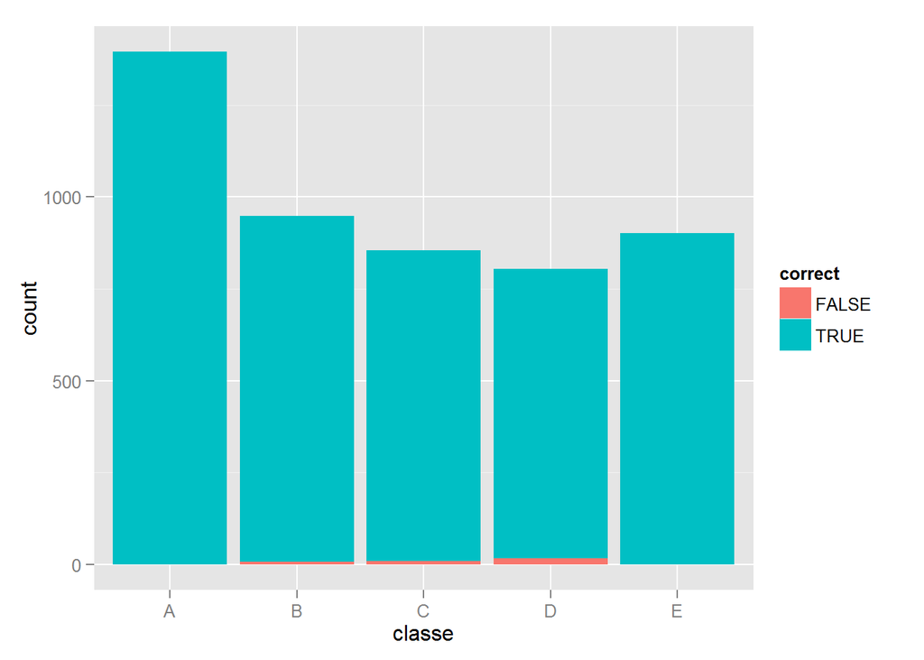

```r
qplot(classe, fill=correct, data=train_validate)
```

Finally, we want to use the model to predict classe on the test dataset.

```r
predict_test <- predict(model1, test_clean)
predict_test
```

```
##  [1] B A B A A E D B A A B C B A E E A B B B
## Levels: A B C D E
```